# RMarkdown Demo

Rosie

2024-03-25

## Code chunk options

Your R Markdown is broken up into ‘code’ chunks and text or ‘markdown’ chunks. Making nice looking R Markdown documents means understanding how to format your code chunks and markdown chunks appropriately.

https://yihui.org/knitr/options/

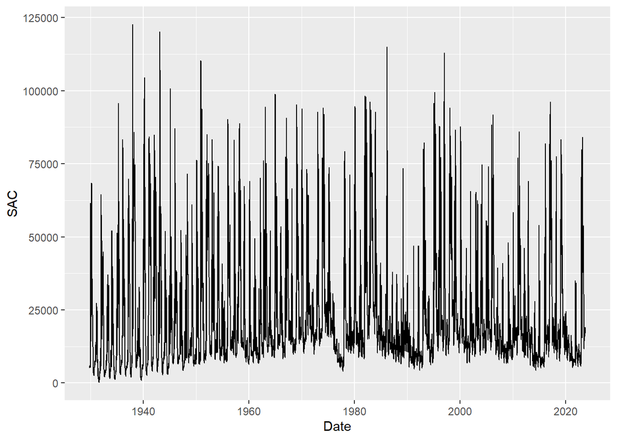

## Formatting Markdown chunks

A few hints for the markdown chunks:

- You need two carriage returns to start a new line.
- Asterisks or dashes make bullets
- Hash tag indicate headings
- You can use html for fancy formatting
- css sheets are used for very fancy formatting (not covered here)
- Use backticks to put code in text blocks `function(x)`

R Markdown is an easy-to-write plain text format for creating dynamic documents and reports. See [Using R Markdown](https://rmarkdown.rstudio.com/) to learn more.

## Figures

You can include figures in a text chunk

image:

[figure not shown]

Or you can include them in code chunks.

[figure not shown]

By default, tables just print like they do in the consul when you knit the document

```r
test = data.frame(Year = c(2000:2023), X =c(0:23), Y = c("Apple", "banana", "cheese"),
                  Z = c(exp(1), pi, exp(2)))

print(test)
```

```
##    Year  X      Y        Z
## 1  2000  0  Apple 2.718282
## 2  2001  1 banana 3.141593
## 3  2002  2 cheese 7.389056
## 4  2003  3  Apple 2.718282
## 5  2004  4 banana 3.141593
## 6  2005  5 cheese 7.389056
## 7  2006  6  Apple 2.718282
## 8  2007  7 banana 3.141593
## 9  2008  8 cheese 7.389056
## 10 2009  9  Apple 2.718282
## 11 2010 10 banana 3.141593
## 12 2011 11 cheese 7.389056
## 13 2012 12  Apple 2.718282
## 14 2013 13 banana 3.141593
## 15 2014 14 cheese 7.389056
## 16 2015 15  Apple 2.718282
## 17 2016 16 banana 3.141593
## 18 2017 17 cheese 7.389056
## 19 2018 18  Apple 2.718282
## 20 2019 19 banana 3.141593
## 21 2020 20 cheese 7.389056
## 22 2021 21  Apple 2.718282
## 23 2022 22 banana 3.141593
## 24 2023 23 cheese 7.389056
```

You can do better with the `kable` function in the `knitr` package

```r
kable(test, format = "pipe", caption = "A prettier table", digits =2, padding =2)
```

A prettier table

| Year | X | Y | Z |
| --- | --- | --- | --- |
| 2000 | 0 | Apple | 2.72 |
| 2001 | 1 | banana | 3.14 |
| 2002 | 2 | cheese | 7.39 |
| 2003 | 3 | Apple | 2.72 |
| 2004 | 4 | banana | 3.14 |
| 2005 | 5 | cheese | 7.39 |
| 2006 | 6 | Apple | 2.72 |
| 2007 | 7 | banana | 3.14 |
| 2008 | 8 | cheese | 7.39 |
| 2009 | 9 | Apple | 2.72 |
| 2010 | 10 | banana | 3.14 |
| 2011 | 11 | cheese | 7.39 |
| 2012 | 12 | Apple | 2.72 |
| 2013 | 13 | banana | 3.14 |
| 2014 | 14 | cheese | 7.39 |
| 2015 | 15 | Apple | 2.72 |
| 2016 | 16 | banana | 3.14 |
| 2017 | 17 | cheese | 7.39 |
| 2018 | 18 | Apple | 2.72 |
| 2019 | 19 | banana | 3.14 |
| 2020 | 20 | cheese | 7.39 |
| 2021 | 21 | Apple | 2.72 |
| 2022 | 22 | banana | 3.14 |
| 2023 | 23 | cheese | 7.39 |

You can make interactive and sortable tables with the `DT` package. https://rstudio.github.io/DT/

```r
library(DT)

datatable(test, filter = "top", class = "cell-border stripe")
```

|  | Year | X | Y | Z |
| --- | --- | --- | --- | --- |
| 1 | 2000 | 0 | Apple | 2.718281828459045 |
| 2 | 2001 | 1 | banana | 3.141592653589793 |
| 3 | 2002 | 2 | cheese | 7.38905609893065 |
| 4 | 2003 | 3 | Apple | 2.718281828459045 |
| 5 | 2004 | 4 | banana | 3.141592653589793 |
| 6 | 2005 | 5 | cheese | 7.38905609893065 |
| 7 | 2006 | 6 | Apple | 2.718281828459045 |
| 8 | 2007 | 7 | banana | 3.141592653589793 |
| 9 | 2008 | 8 | cheese | 7.38905609893065 |
| 10 | 2009 | 9 | Apple | 2.718281828459045 |

[output cut: 14 more lines]

## Further Reading

There are lots and lots of extensions you can add to your markdown documetns to make them really, really spiffy. A few examples:

- HTML widgets such as `leaflet` for [maps](https://rpubs.com/jcheng/leaflet-layers-example) - https://cran.r-project.org/web/packages/leaflet/index.html
- Interactive [dashboards](https://gallery.shinyapps.io/cran-gauge/) - https://pkgs.rstudio.com/flexdashboard/
- Interactive graphs - https://cran.r-project.org/web/packages/dygraphs/index.html
- Web books ([bookdown](https://pkgs.rstudio.com/bookdown/articles/examples.html), up next)
- [Shiny](https://shiny.posit.co/r/gallery/) web apps (coming up soon)
- https://rmarkdown.rstudio.com/gallery.html